# Problems-004

```python
# We always start with this!
%pylab inline
```

## 1) Devilish Debugging

Oh no! I wrote a simple little function to remove all instances of the number 6 from a list, and *it doesn't work!* There must be something terribly *evil* about the number 6.

Can you figure out the problem, and fix my function?

```python
def remove_all_6s(lst):
    """Removes all 6s in a list, and returns the list."""
    for n in lst:
        if n == 6:
            lst.remove(n)
    return lst

remove_all_6s([1,6,6,3,3,6,4,6,5])
```

```
[1, 3, 3, 4, 6, 5]
```

##### Hints:

1. Modify the code in a hundred different ways, just to see what happens!
2. Try using `print` inside the function to see what is happening at each iteration.
3. Think about what happens when you remove an item from a list *in the middle of a* `for` *loop*. How could you avoid this?

### 1b) To zip or not to zip

The `zip` function allows you to iterate through 2 or more lists at the same time:

```python
my_list1 = [1, 2, 3, 4]
my_list2 = [10, 20, 30, 40]

for n,m in zip(my_list1, my_list2):
    print(n, '+', m, '=', n + m)
```

```
1 + 10 = 11
2 + 20 = 22
3 + 30 = 33
4 + 40 = 44
```

How is this different from "nesting" for loops? What happens if I run the following code? How is this different from using `zip` like above?

```
my_list1 = [1, 2, 3, 4]
my_list2 = [10, 20, 30, 40]

for n in my_list1:
    for m in my_list2:
        print(n, '+', m, '=', n + m)
```

## 2) Shopping list for pumpkin pie

It is fall season - time to bake a pumkin pie! Because I don't really remember what goes into a pumpkin pie, I looked up a [recipe](http://allrecipes.com/recipe/23439/perfect-pumpkin-pie/). We can keep the needed ingredients in a python list of strings.

```
ingredients = ["pumpkin","sweetened condensed milk","eggs","cinnamon","ginger","nutmeg","salt","pie crust"]
```

It turns out I have a bunch of stuff in `stock`, but not all of it can be used for making my pie.

```
stock = ["chair","salt","milk","eggs","flour","lemon juice","frozen fish","apples","sugar","dish washing soap","sweetened condensed milk","ginger","garlic","pumpkin","potatoes"]
```

### 2a) What do I need to buy?

Write a function `shoppinglist(ingredients, stock)` that will return a list with all the items that I need for the pie but I don't have in `stock`.

### 2b) What's left in stock?

Write a function `update_stock` that removes all items from stock that I will be using for the pie. The function should return an updated `stock` list. Assume that an item gets used up entirely when I bake my pie.

## 3) Smiley competition

Let's draw some smiley faces!

Let's start with the following code:

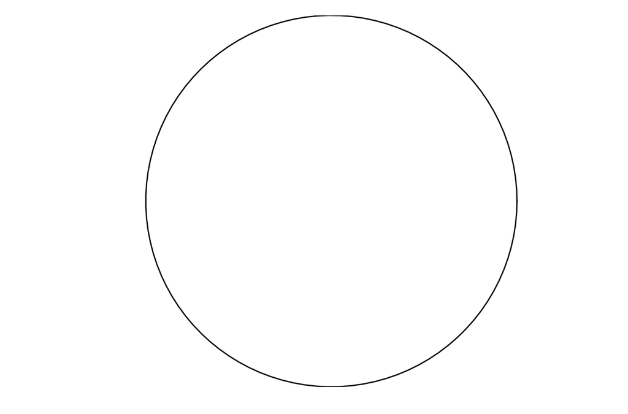

```python
def draw_circle(radius, npoints=100):
    angles = linspace(0, 2*pi, npoints)
    xs = cos(angles) * radius
    ys = sin(angles) * radius

    plot(xs, ys, 'k-')
    axis('equal')
    axis('off')

draw_circle(2.0)
```

#### 3a) Modify the above code to be able to plot a circle at a different center or with a different angle.

##### Example function signature:

```
def draw_circle(radius, center_x=0, center_y=0, start_angle=0.0, end_angle=2*pi, npoints=100):
    # Your code here
```

#### 3b) Use this function to draw a smiley face!

You can use a circle for the edge of the face, a circle for each of the eyes, and a partial circle (with `start_angle` and `end_angle` different from 0 and $2 \pi$) for the smile.

I made the following one before class:

[figure not shown]

## 4) Extending the Heaviside function to arrays

In class we defined the Heavside function in python as `step(x)`. Unfortunaley it does not work on arrays yet, meaning if the input `x` is an array python will return an error. Use your method of choice (smart indexing or for loops) to redefine `step(x)` as `better_step(x)` such that it will work on arrays too. You may use your own definition of `step(x)` or you can use the one provided below.

```
def step(x):
    "This is the Heaviside step function. It returns 0 for x values below 0, 1/2 for x = 0, and 1 for x > 0."
    if x < 0:
        return 0
    elif x == 0:
        return 0.5
    else:
        return 1
```

##### Check your function by plotting the output in the range from -1 to +1:

```
x = linspace(-1,1,num = 1000)
y = better_step(x)
plot(x,y,'o')
```

## 5) Finding Prime numbers

### 5a) Write a program that finds all the factors of a number.

##### Example output:

```
>>> get_factors(7)
[1, 7]
>>> get_factors(12)
[1, 2, 3, 4, 6, 12]
```

##### Hints:

You can use `for i in range(n, m+1):` to loop over all numbers between `n` and `m` inclusively.

To check if `x` is divisible by `y`, you can use the modulo (or remainder) operator:

```
>>> 12 % 3 == 0
True
>>> 12 % 5 == 0
False
```

### 5b) Write a function that tests if a number is prime.

Remember that a number is *prime* if its only two factors are 1 and itself.

##### Example output:

```
>>> is_prime(7)
True
>>> is_prime(12)
False
```

##### Hints:

You can use the `get_factors` function we defined above!

### 5c) Print all the prime numbers less than 100.

##### Example output:

```
2
3
5
7
11
13
17
19
...
```